# Categorical Predictors and Interactions

STAT 665

2/28/2017

## Rail Trail Data

> http://www.mass.gov/eea/agencies/dcr/massparks/region-west/norwottuck-rail-trail.html

The Norwottuck Rail Trail is a public green space in Western Massachusetts covering 11 miles of what used to be railroad tracks. Between April 5 and November 15, 2005, data collectors set up a laser sensor at a specific location along the Rail Trail to study daily volumes of people who use the trail. More precisely, the laser beam would detect when there were breaks in the laser beam recording; these breaks would then be used to count the number of trail users.

```r
x <- read.csv("RailTrail.csv", as.is=T)
head(x)
```

```
##   hightemp lowtemp avgtemp spring summer fall cloudcover precip volume
## 1       83      50    66.5      0      1    0        7.6   0.00    501
## 2       73      49    61.0      0      1    0        6.3   0.29    419
## 3       74      52    63.0      1      0    0        7.5   0.32    397
## 4       95      61    78.0      0      1    0        2.6   0.00    385
## 5       44      52    48.0      1      0    0       10.0   0.14    200
## 6       69      54    61.5      1      0    0        6.6   0.02    375
##        weekday
## 1         wkdy
## 2         wkdy
## 3         wkdy
## 4 wknd/holiday
## 5         wkdy
## 6         wkdy
```

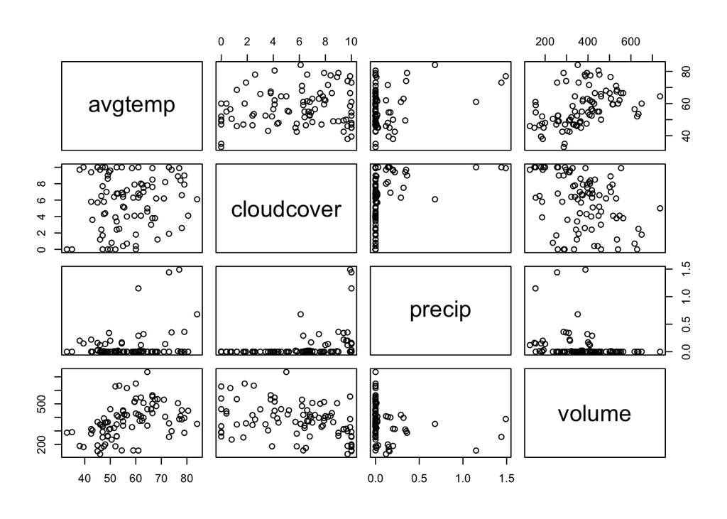

```r
plot(x[,c(3,7:9)])
```

Starting with a simple linear regression model:

```r
m1 <- lm(volume ~ avgtemp, data=x)
summary(m1)
```

```
##
## Call:
## lm(formula = volume ~ avgtemp, data = x)
##
## Residuals:
##     Min      1Q  Median      3Q     Max
## -237.53  -80.00    8.49   55.14  326.67
##
## Coefficients:
##             Estimate Std. Error t value Pr(>|t|)
## (Intercept)   99.602     63.474   1.569     0.12
## avgtemp        4.802      1.084   4.428 2.72e-05 ***
## ---
## Signif. codes:  0 '***' 0.001 '**' 0.01 '*' 0.05 '.' 0.1 ' ' 1
##
## Residual standard error: 115.9 on 88 degrees of freedom
## Multiple R-squared:  0.1822, Adjusted R-squared:  0.1729
## F-statistic: 19.61 on 1 and 88 DF,  p-value: 2.723e-05
```

Now considering the `weekday` variable:

```r
x$weekday <- factor(x$weekday)
table(x$weekday)
```

```
##
##         wkdy wknd/holiday
##           62           28
```

```r
m2 <- lm(volume ~ avgtemp + weekday, data=x)
summary(m2)
```

```
##
## Call:
## lm(formula = volume ~ avgtemp + weekday, data = x)
##
## Residuals:
##     Min      1Q  Median      3Q     Max
## -242.92  -75.72    3.15   66.90  280.06
##
## Coefficients:
##                     Estimate Std. Error t value Pr(>|t|)
## (Intercept)           92.701     61.282   1.513  0.13398
## avgtemp                4.541      1.050   4.323 4.08e-05 ***
## weekdaywknd/holiday   70.320     25.566   2.751  0.00724 **
## ---
## Signif. codes:  0 '***' 0.001 '**' 0.01 '*' 0.05 '.' 0.1 ' ' 1
##
## Residual standard error: 111.8 on 87 degrees of freedom
## Multiple R-squared:  0.2476, Adjusted R-squared:  0.2303
## F-statistic: 14.32 on 2 and 87 DF,  p-value: 4.214e-06
```

```r
m2c <- coef(m2)
m2c
```

```
##         (Intercept)             avgtemp weekdaywknd/holiday
##           92.701296            4.541287           70.320318
```

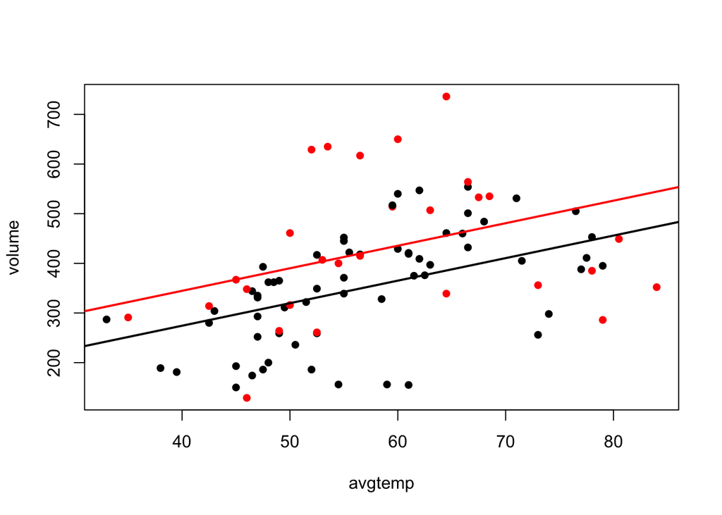

```r
plot(volume ~ avgtemp, data=x, pch=16, col=weekday)
abline(a= m2c[1], b= m2c[2], col=1, lwd=2)
abline(a= m2c[1] + m2c[3], b= m2c[2], col=2, lwd=2)
```

Interacting weekday and average temp allows for the possibility of different slopes:

```r
m3 <- lm(volume ~ avgtemp * weekday, data=x)
summary(m3)
```

```
##
## Call:
## lm(formula = volume ~ avgtemp * weekday, data = x)
##
## Residuals:
##      Min       1Q   Median       3Q      Max
## -269.906  -78.862    2.064   68.190  291.641
##
## Coefficients:
##                             Estimate Std. Error t value Pr(>|t|)
## (Intercept)                   23.695     75.768   0.313   0.7552
## avgtemp                        5.757      1.312   4.389 3.22e-05 ***
## weekdaywknd/holiday          262.193    128.181   2.045   0.0439 *
## avgtemp:weekdaywknd/holiday   -3.300      2.161  -1.527   0.1304
## ---
## Signif. codes:  0 '***' 0.001 '**' 0.01 '*' 0.05 '.' 0.1 ' ' 1
##
## Residual standard error: 111 on 86 degrees of freedom
## Multiple R-squared:  0.2675, Adjusted R-squared:  0.2419
## F-statistic: 10.47 on 3 and 86 DF,  p-value: 6.115e-06
```

$$\widehat{volume} = 23.7 + 5.76avgtemp + 262 wknd - 3.30 avgtemp\times wknd$$

The model for predicting traffic on weekdays (‘wknd’ is 0 in above equation):

$$\widehat{volume} = 23.7 + 5.76avgtemp$$

The model for predicting traffic on weekends and holidays (‘wknd’ is 1 in above equation):

$$\widehat{volume} = 285.7 + 2.46avgtemp$$

```r
m3c <- coef(m3)
m3c
```

```
##                 (Intercept)                     avgtemp
##                   23.694772                    5.757261
##         weekdaywknd/holiday avgtemp:weekdaywknd/holiday
##                  262.192662                   -3.300338
```

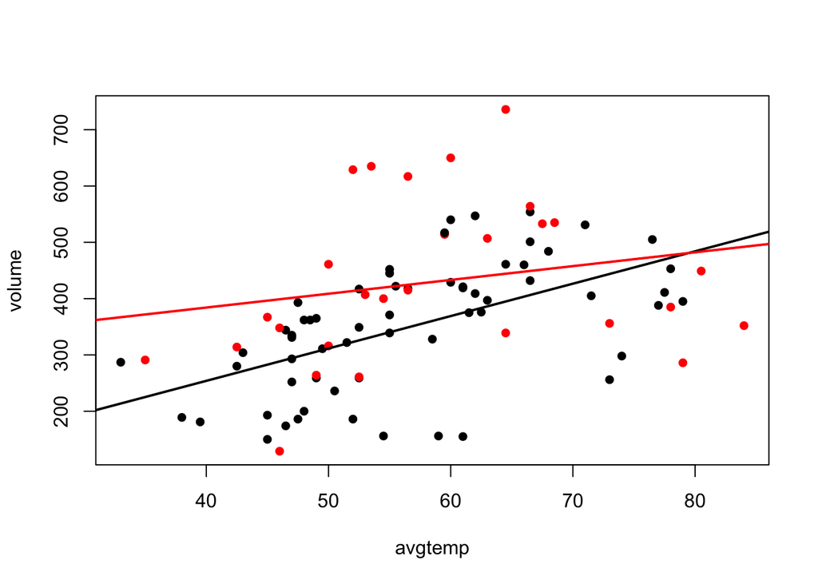

```r
plot(volume ~ avgtemp, data=x, pch=16, col=weekday)
abline(a= m3c[1], b= m3c[2], col=1, lwd=2)
abline(a= m3c[1] + m3c[3], b= m3c[2] + m3c[4], col=2, lwd=2)
```

```r
summary(m3)
```

```
##
## Call:
## lm(formula = volume ~ avgtemp * weekday, data = x)
##
## Residuals:
##      Min       1Q   Median       3Q      Max
## -269.906  -78.862    2.064   68.190  291.641
##
## Coefficients:
##                             Estimate Std. Error t value Pr(>|t|)
## (Intercept)                   23.695     75.768   0.313   0.7552
## avgtemp                        5.757      1.312   4.389 3.22e-05 ***
## weekdaywknd/holiday          262.193    128.181   2.045   0.0439 *
## avgtemp:weekdaywknd/holiday   -3.300      2.161  -1.527   0.1304
## ---
## Signif. codes:  0 '***' 0.001 '**' 0.01 '*' 0.05 '.' 0.1 ' ' 1
##
## Residual standard error: 111 on 86 degrees of freedom
## Multiple R-squared:  0.2675, Adjusted R-squared:  0.2419
## F-statistic: 10.47 on 3 and 86 DF,  p-value: 6.115e-06
```

Considering cloudcover or precip…

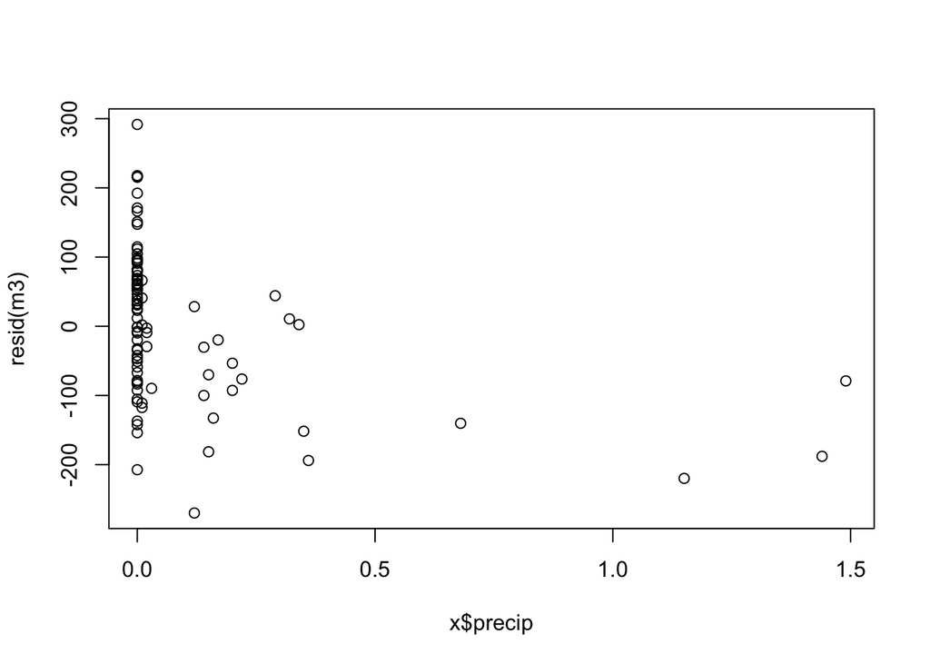

```r
plot(resid(m3) ~ x$precip)
```

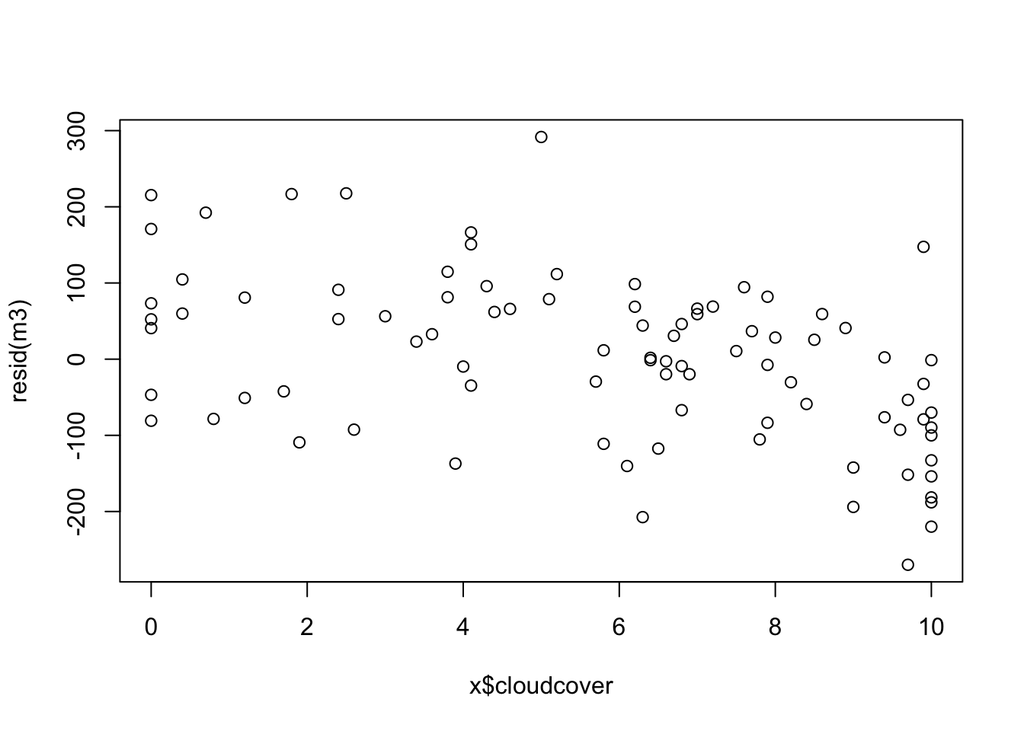

```r
plot(resid(m3) ~ x$cloudcover)
```

Cloudcover looks promising (negatively associated with residuals from the previous model).

```r
m4 <- lm(volume ~ avgtemp * weekday + cloudcover, data=x)
summary(m4)
```

```
##
## Call:
## lm(formula = volume ~ avgtemp * weekday + cloudcover, data = x)
##
## Residuals:
##      Min       1Q   Median       3Q      Max
## -208.734  -53.335    6.217   61.652  293.977
##
## Coefficients:
##                             Estimate Std. Error t value Pr(>|t|)
## (Intercept)                   57.718     66.836   0.864  0.39026
## avgtemp                        7.040      1.178   5.976 5.19e-08 ***
## weekdaywknd/holiday          321.116    113.097   2.839  0.00566 **
## cloudcover                   -17.198      3.334  -5.158 1.61e-06 ***
## avgtemp:weekdaywknd/holiday   -4.727      1.917  -2.466  0.01568 *
## ---
## Signif. codes:  0 '***' 0.001 '**' 0.01 '*' 0.05 '.' 0.1 ' ' 1
##
## Residual standard error: 97.42 on 85 degrees of freedom
## Multiple R-squared:  0.4421, Adjusted R-squared:  0.4159
## F-statistic: 16.84 on 4 and 85 DF,  p-value: 3.344e-10
```

### Checking assumptions

Normality of errors:

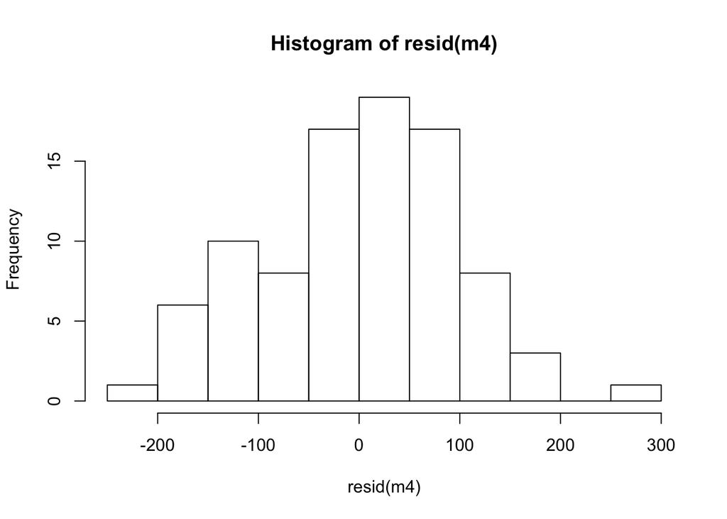

```r
hist(resid(m4))
```

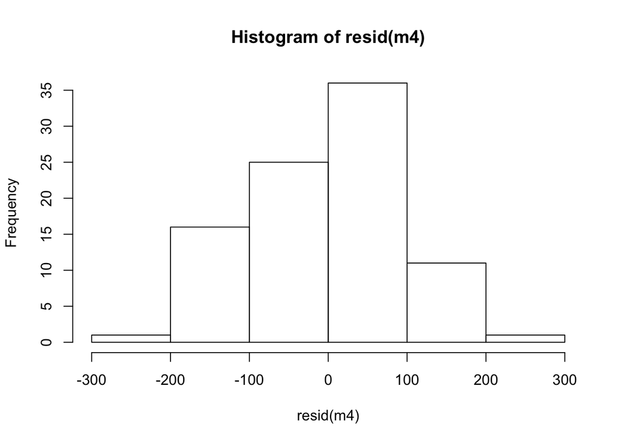

```r
hist(resid(m4), breaks=5)
```

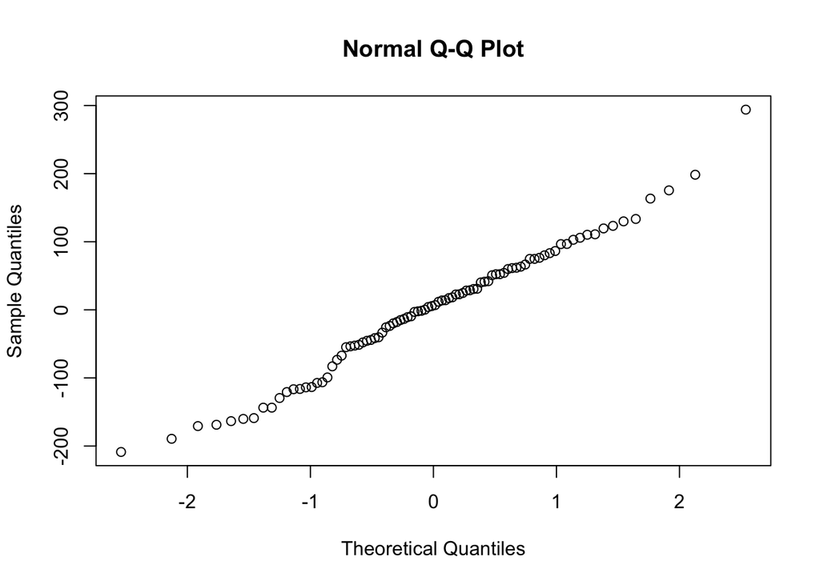

```r
qqnorm(resid(m4))
```

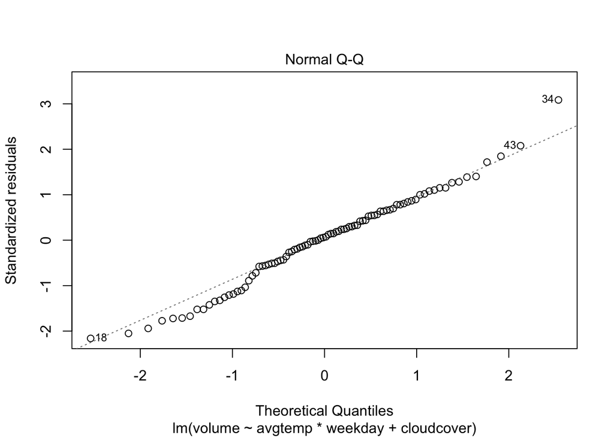

```r
plot(m4, which=2)
```

From this qq-plot, we are looking for a close to diagonal line formed by the points.

Equal variance assumption:

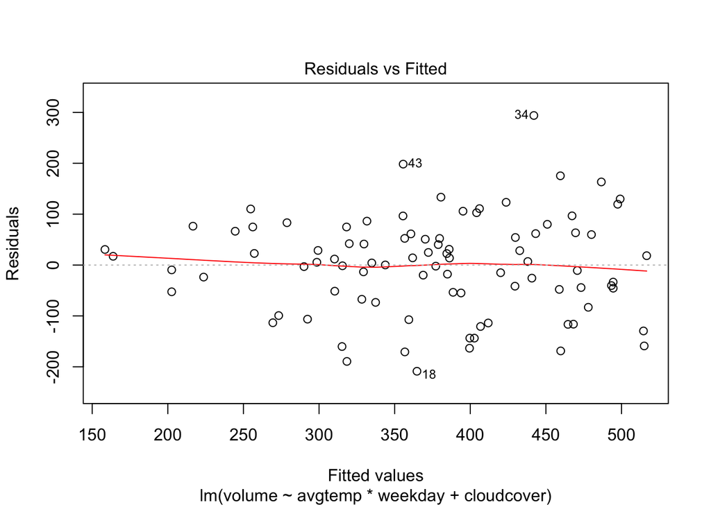

```r
plot(m4, which=1)
```

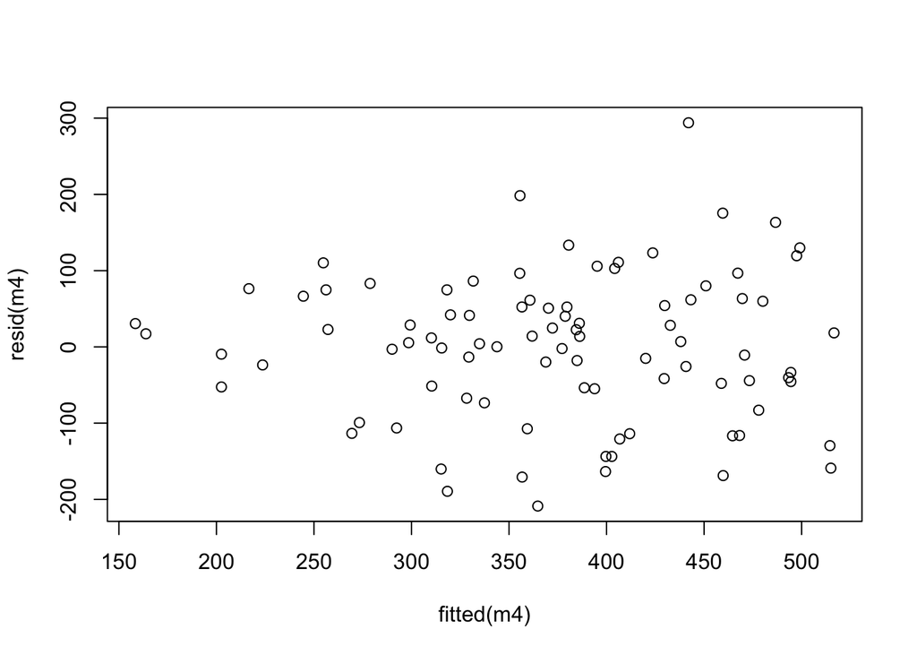

```r
plot(resid(m4) ~ fitted(m4))
```

Generally, with this plot, we’re hoping to see no consistent patterns. For the equal variance assumption, we are looking for a consistent amount of vertical scatter as we look at the plot from left to right.

## Back to ATUS

Load in the dataset:

```r
# x <- read.csv("atus_social.csv", as.is = TRUE)
x <- read.csv("https://www.dropbox.com/s/c7gidc2stjh3a2k/atus_social.csv?raw=1",
              as.is = TRUE)
head(x)
```

```
##      tucaseid age sex                      edu       race hispanic metro
## 1 2.01401e+13  20   F   2. high school diploma White only      Yes   Yes
## 2 2.01401e+13  16   F 1. < high school diploma Black only       No   Yes
## 3 2.01401e+13  65   F 1. < high school diploma White only      Yes   Yes
## 4 2.01401e+13  50   F   2. high school diploma Black only       No    No
## 5 2.01401e+13  23   F   2. high school diploma Black only       No    No
## 6 2.01401e+13  85   M 1. < high school diploma Black only       No   Yes
##   social_time num_children weekly_earn diary_date              famincome
## 1          30            1          NA   20140126            1. < $5,000
## 2         200            1     1846.15   20140130 11. $40,000 to $49,999
## 3         255            3          NA   20140127 10. $35,000 to $39,999
## 4         460            0          NA   20140126            1. < $5,000
## 5         120            1          NA   20140129    3. $7,500 to $9,999
## 6        1140            0          NA   20140126 13. $60,000 to $74,999
##   hh_size
## 1       1
## 2       2
## 3       6
## 4       1
## 5       2
## 6       2
```

## Incorporating Diary Date

```r
head(x$diary_date)
```

```
## [1] 20140126 20140130 20140127 20140126 20140129 20140126
```

```r
class(x$diary_date)
```

```
## [1] "integer"
```

```r
#install.packages("lubridate")
library(lubridate)
x$diary_date <- ymd(x$diary_date)
head(x$diary_date)
```

```
## [1] "2014-01-26" "2014-01-30" "2014-01-27" "2014-01-26" "2014-01-29"
## [6] "2014-01-26"
```

```r
class(x$diary_date)
```

```
## [1] "Date"
```

```r
x$wday <- wday(x$diary_date)
table(x$wday)
```

```
##
##    1    2    3    4    5    6    7
## 2864 1108 1142 1122 1091 1113 2679
```

```r
x$wday <- factor(wday(x$diary_date, label=TRUE), ordered=FALSE)
table(x$wday)
```

```
##
##   Sun   Mon  Tues   Wed Thurs   Fri   Sat
##  2864  1108  1142  1122  1091  1113  2679
```

```r
class(x$wday)
```

```
## [1] "factor"
```

```r
m4 <- lm(social_time ~ age + I(age^2) + sex + wday, data=x)
head(model.matrix(m4))
```

```
##   (Intercept) age I(age^2) sexM wdayMon wdayTues wdayWed wdayThurs wdayFri
## 1           1  20      400    0       0        0       0         0       0
## 2           1  16      256    0       0        0       0         1       0
## 3           1  65     4225    0       1        0       0         0       0
## 4           1  50     2500    0       0        0       0         0       0
## 5           1  23      529    0       0        0       1         0       0
## 6           1  85     7225    1       0        0       0         0       0
##   wdaySat
## 1       0
## 2       0
## 3       0
## 4       0
## 5       0
## 6       0
```

A categorical variable with $K$ levels can be encoded using $K-1$ dummy variables (indicators). These $K-1$ indicators are not independent: for each row, at most one of them will have the value 1, while the others will be 0’s. If there are no 1’s, then we know that the row corresponds to the baseline reference level (here that would be Sunday, since there is no explicit indicator for Sundays).

```r
summary(m4)
```

```
##
## Call:
## lm(formula = social_time ~ age + I(age^2) + sex + wday, data = x)
##
## Residuals:
##    Min     1Q Median     3Q    Max
## -576.2 -141.1  -31.1  116.1 1085.7
##
## Coefficients:
##               Estimate Std. Error t value Pr(>|t|)
## (Intercept) 402.899556  13.415876  30.032   <2e-16 ***
## age          -8.139729   0.557168 -14.609   <2e-16 ***
## I(age^2)      0.118764   0.005528  21.485   <2e-16 ***
## sexM         42.641456   3.782602  11.273   <2e-16 ***
## wdayMon     -86.759975   6.998111 -12.398   <2e-16 ***
## wdayTues    -93.692871   6.923076 -13.533   <2e-16 ***
## wdayWed     -91.402053   6.966500 -13.120   <2e-16 ***
## wdayThurs   -99.460546   7.037803 -14.132   <2e-16 ***
## wdayFri     -61.403509   6.986859  -8.788   <2e-16 ***
## wdaySat       7.064279   5.318063   1.328    0.184
## ---
## Signif. codes:  0 '***' 0.001 '**' 0.01 '*' 0.05 '.' 0.1 ' ' 1
##
## Residual standard error: 197.8 on 11109 degrees of freedom
##   (231 observations deleted due to missingness)
## Multiple R-squared:  0.1735, Adjusted R-squared:  0.1729
## F-statistic: 259.2 on 9 and 11109 DF,  p-value: < 2.2e-16
```

All of the `wday` coefficients in this output are actually comparing each labeled day of the week to Sunday, our reference level. Based on the coefficients, we can see that Mondays and Thursdays are fairly similar – on average, respondents spent about 90 minutes less time socializing/relaxing on these days than on Sunday. Friday seemed to be a bit better, such that respondents spent only 60 minutes less time socializing/relaxing compared to Sunday. Saturday and Sunday are about the same – the p-value suggests that people on average spend about the same time socializing on Saturday and Sundays.

What about fitting a “Friday effect”? After all, we saw that Fridays are somewhat different from regular workdays and weekends:

```r
x$daytype <- ifelse(x$wday %in% c("Sat", "Sun"), "Wknd", "M_Th")
x$daytype[x$wday == "Fri"] <- "Fri"
table(x$daytype, x$wday)
```

```
##
##         Sun  Mon Tues  Wed Thurs  Fri  Sat
##   Fri     0    0    0    0     0 1113    0
##   M_Th    0 1108 1142 1122  1091    0    0
##   Wknd 2864    0    0    0     0    0 2679
```

```r
m5a <- lm(social_time ~ age + I(age^2) + sex + daytype, data=x)
summary(m5a)
```

```
##
## Call:
## lm(formula = social_time ~ age + I(age^2) + sex + daytype, data = x)
##
## Residuals:
##     Min      1Q  Median      3Q     Max
## -572.36 -140.94  -31.33  115.77 1084.85
##
## Coefficients:
##               Estimate Std. Error t value Pr(>|t|)
## (Intercept) 341.538743  14.248605  23.970  < 2e-16 ***
## age          -8.138435   0.557102 -14.609  < 2e-16 ***
## I(age^2)      0.118723   0.005527  21.481  < 2e-16 ***
## sexM         42.658117   3.782233  11.279  < 2e-16 ***
## daytypeM_Th -31.403852   6.627338  -4.739 2.18e-06 ***
## daytypeWknd  64.815816   6.497439   9.976  < 2e-16 ***
## ---
## Signif. codes:  0 '***' 0.001 '**' 0.01 '*' 0.05 '.' 0.1 ' ' 1
##
## Residual standard error: 197.8 on 11113 degrees of freedom
##   (231 observations deleted due to missingness)
## Multiple R-squared:  0.1732, Adjusted R-squared:  0.1728
## F-statistic: 465.7 on 5 and 11113 DF,  p-value: < 2.2e-16
```

Is this model better or worse than our model with all the days of the week?

```r
summary(m4)$r.sq
```

```
## [1] 0.1735276
```

```r
summary(m5a)$r.sq
```

```
## [1] 0.1732215
```

```r
extractAIC(m4)
```

```
## [1]     10.0 117587.4
```

```r
extractAIC(m5a)
```

```
## [1]      6.0 117583.5
```

We also considered modeling just a weekday vs. weekend effect, bundling up Fridays with the other days.

```r
x$wknd <- x$wday %in% c("Sat", "Sun")
table(x$wknd, x$wday)
```

```
##
##          Sun  Mon Tues  Wed Thurs  Fri  Sat
##   FALSE    0 1108 1142 1122  1091 1113    0
##   TRUE  2864    0    0    0     0    0 2679
```

```r
m5 <- lm(social_time ~ age + I(age^2) + sex + wknd, data=x)
summary(m5)
```

```
##
## Call:
## lm(formula = social_time ~ age + I(age^2) + sex + wknd, data = x)
##
## Residuals:
##     Min      1Q  Median      3Q     Max
## -572.52 -141.03  -30.59  115.96 1078.59
##
## Coefficients:
##               Estimate Std. Error t value Pr(>|t|)
## (Intercept) 316.172628  13.217526   23.92   <2e-16 ***
## age          -8.131190   0.557637  -14.58   <2e-16 ***
## I(age^2)      0.118692   0.005532   21.45   <2e-16 ***
## sexM         42.566350   3.785832   11.24   <2e-16 ***
## wkndTRUE     89.952847   3.755373   23.95   <2e-16 ***
## ---
## Signif. codes:  0 '***' 0.001 '**' 0.01 '*' 0.05 '.' 0.1 ' ' 1
##
## Residual standard error: 198 on 11114 degrees of freedom
##   (231 observations deleted due to missingness)
## Multiple R-squared:  0.1716, Adjusted R-squared:  0.1713
## F-statistic: 575.4 on 4 and 11114 DF,  p-value: < 2.2e-16
```

You should review notes from last class to see how this model translates into a fitted equation.

How does this model compare to the previous one?

```r
summary(m5a)$r.sq
```

```
## [1] 0.1732215
```

```r
summary(m5)$r.sq
```

```
## [1] 0.171551
```

```r
extractAIC(m5a)
```

```
## [1]      6.0 117583.5
```

```r
extractAIC(m5)
```

```
## [1]      5.0 117603.9
```

In summary, if we were using AIC as the measure for comparison, we would prefer the model that breaks the relationship down into a Monday-Thursday, Friday, and a Weekend effect. This means that our model is fitting 6 parallel parabolas.

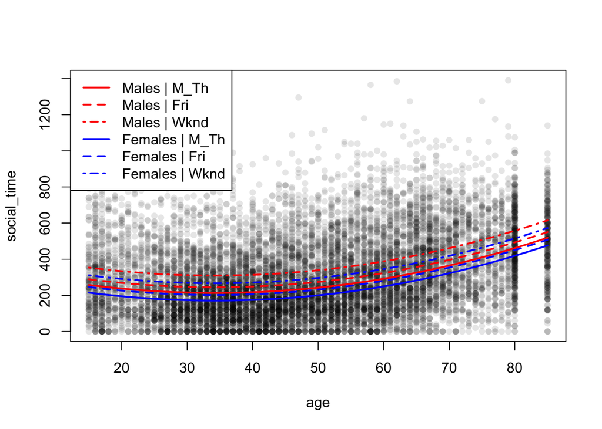

```r
myfun <- function(sex, daytype, model) {
  vals <- predict(model, data.frame(age = 15:85, sex = sex, daytype = daytype))
  return(vals)
}

plot(social_time ~ age, data=x, pch=16, col=rgb(0,0,0,0.1))
lines(15:85, myfun("M", "M_Th", m5a), col="red", lwd=2)
lines(15:85, myfun("M", "Fri", m5a), col="red", lwd=2, lty=2)
lines(15:85, myfun("M", "Wknd", m5a), col="red", lwd=2, lty=4)
lines(15:85, myfun("F", "M_Th", m5a), col="blue", lwd=2)
lines(15:85, myfun("F", "Fri", m5a), col="blue", lwd=2, lty=2)
lines(15:85, myfun("F", "Wknd", m5a), col="blue", lwd=2, lty=4)

legend("topleft", col=rep(c("red", "blue"), each=3), lwd=2, lty=rep(c(1,2,4),
                                                                    times=2),
       legend=c("Males | M_Th", "Males | Fri", "Males | Wknd",
                "Females | M_Th", "Females | Fri", "Females | Wknd"))
```

Suppose we want to interact sex and daytype to allow for, say, weekends to affect time spent socializing differently between males and females:

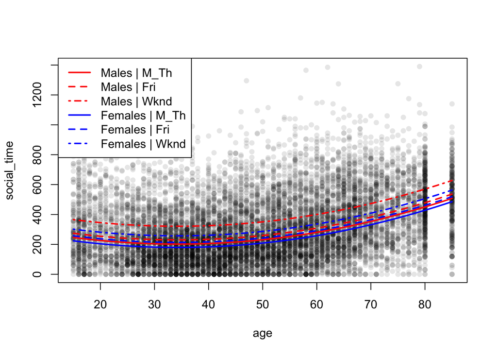

```r
m6 <- lm(social_time ~ age + I(age^2) + sex * daytype, data = x)


plot(social_time ~ age, data=x, pch=16, col=rgb(0,0,0,0.1))
lines(15:85, myfun("M", "M_Th", m6), col="red", lwd=2)
lines(15:85, myfun("M", "Fri", m6), col="red", lwd=2, lty=2)
lines(15:85, myfun("M", "Wknd", m6), col="red", lwd=2, lty=4)
lines(15:85, myfun("F", "M_Th", m6), col="blue", lwd=2)
lines(15:85, myfun("F", "Fri", m6), col="blue", lwd=2, lty=2)
lines(15:85, myfun("F", "Wknd", m6), col="blue", lwd=2, lty=4)

legend("topleft", col=rep(c("red", "blue"), each=3), lwd=2, lty=rep(c(1,2,4),
                                                                    times=2),
       legend=c("Males | M_Th", "Males | Fri", "Males | Wknd",
                "Females | M_Th", "Females | Fri", "Females | Wknd"))
```

```r
summary(m6)
```

```
##
## Call:
## lm(formula = social_time ~ age + I(age^2) + sex * daytype, data = x)
##
## Residuals:
##     Min      1Q  Median      3Q     Max
## -563.28 -139.88  -30.78  114.26 1096.28
##
## Coefficients:
##                   Estimate Std. Error t value Pr(>|t|)
## (Intercept)      352.76750   15.04421  23.449  < 2e-16 ***
## age               -8.16180    0.55636 -14.670  < 2e-16 ***
## I(age^2)           0.11903    0.00552  21.564  < 2e-16 ***
## sexM              17.46573   11.95005   1.462 0.143890
## daytypeM_Th      -33.24514    8.80464  -3.776 0.000160 ***
## daytypeWknd       44.30694    8.63381   5.132 2.92e-07 ***
## sexM:daytypeM_Th   4.71739   13.34964   0.353 0.723816
## sexM:daytypeWknd  46.71496   13.08726   3.570 0.000359 ***
## ---
## Signif. codes:  0 '***' 0.001 '**' 0.01 '*' 0.05 '.' 0.1 ' ' 1
##
## Residual standard error: 197.5 on 11111 degrees of freedom
##   (231 observations deleted due to missingness)
## Multiple R-squared:  0.1756, Adjusted R-squared:  0.1751
## F-statistic: 338.2 on 7 and 11111 DF,  p-value: < 2.2e-16
```

Equation for predicting how much time males spend socializing on Mondays through Thursdays:

$$\widehat{socialtime} = 353 - 8.16 age + .119 age^2 + 17.47 - 33.2 + 4.717 = 342 - 8.16 age + .119 age^2$$